# Chapter 7: Question 8

Haider Ali, Walker Campbell, Trenton Carpenter, Ian Dors,

2/7/2021

Fit some of the non-linear models investigated in this chapter to the Auto data set. Is there evidence for non-linear relationships in this data set? Create some informative plots to justify your answer.

```r
rm(list = ls())

library(ISLR)
set.seed(1337)
attach(Auto)
head(Auto)
```

```
##   mpg cylinders displacement horsepower weight acceleration year origin
## 1  18         8          307        130   3504         12.0   70      1
## 2  15         8          350        165   3693         11.5   70      1
## 3  18         8          318        150   3436         11.0   70      1
## 4  16         8          304        150   3433         12.0   70      1
## 5  17         8          302        140   3449         10.5   70      1
## 6  15         8          429        198   4341         10.0   70      1
##                        name
## 1 chevrolet chevelle malibu
## 2         buick skylark 320
## 3        plymouth satellite
## 4             amc rebel sst
## 5               ford torino
## 6          ford galaxie 500
```

First, clear the environment.

Import ‘ISLR’ library, set seed for repeatable results, attach the data set, and view the first six rows.

Displacement is the size of the engine in volume.

This data set was taken from the StatLib library which is maintained at Carnegie Mellon University. The data set was used in the 1983 American Statistical Association Exposition.

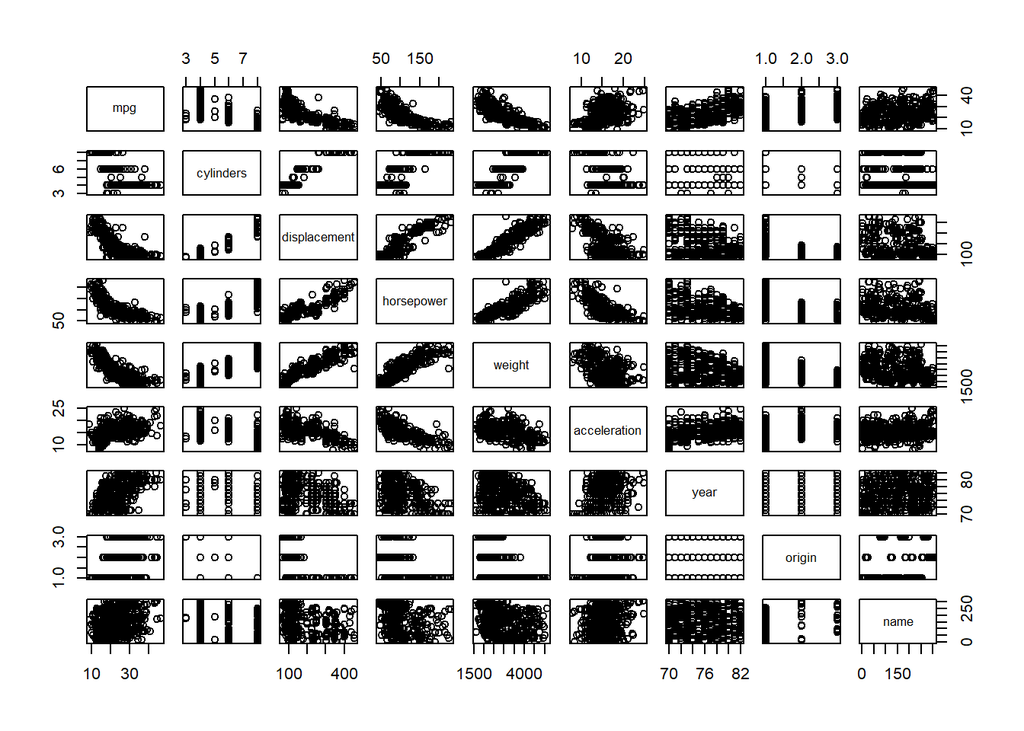

```r
pairs(Auto)
```

Here, we are comparing each feature against another in the data set. We are looking for non-linear relationships. It appears that mpg v displacement is non-linear.

Next, we will create a model to test different exponents of displacement.

```r
fit <- lm(mpg ~ poly(displacement, 5))
summary(fit)
```

```
##
## Call:
## lm(formula = mpg ~ poly(displacement, 5))
##
## Residuals:
##      Min       1Q   Median       3Q      Max
## -15.3360  -2.3445  -0.2895   2.1635  20.3439
##
## Coefficients:
##                         Estimate Std. Error t value Pr(>|t|)
## (Intercept)              23.4459     0.2209 106.158  < 2e-16 ***
## poly(displacement, 5)1 -124.2585     4.3728 -28.416  < 2e-16 ***
## poly(displacement, 5)2   31.0895     4.3728   7.110 5.67e-12 ***
## poly(displacement, 5)3   -4.4655     4.3728  -1.021    0.308
## poly(displacement, 5)4    0.7747     4.3728   0.177    0.859
## poly(displacement, 5)5    3.2991     4.3728   0.754    0.451
## ---
## Signif. codes:  0 '***' 0.001 '**' 0.01 '*' 0.05 '.' 0.1 ' ' 1
##
## Residual standard error: 4.373 on 386 degrees of freedom
## Multiple R-squared:  0.6901, Adjusted R-squared:  0.6861
## F-statistic: 171.9 on 5 and 386 DF,  p-value: < 2.2e-16
```

Here, we are looking for a P-value above .05 because if it is lower than .05, then we are rejecting the null hypothesis (that the model is sufficient)

Looking at the summary of this linear model, we can see that displacement^1 and displacement^2 are not sufficient. However, displacement^3 appears to be sufficient.

Next, we will confirm this with an ANOVA test.

```r
fit1=lm(mpg~displacement)
fit2=lm(mpg~poly(displacement,2))
fit3=lm(mpg~poly(displacement,3))
fit4=lm(mpg~poly(displacement,4))
fit5=lm(mpg~poly(displacement,5))
anova(fit1,fit2,fit3,fit4,fit5)
```

```
## Analysis of Variance Table
##
## Model 1: mpg ~ displacement
## Model 2: mpg ~ poly(displacement, 2)
## Model 3: mpg ~ poly(displacement, 3)
## Model 4: mpg ~ poly(displacement, 4)
## Model 5: mpg ~ poly(displacement, 5)
##   Res.Df    RSS Df Sum of Sq       F    Pr(>F)
## 1    390 8378.8
## 2    389 7412.3  1    966.56 50.5487 5.668e-12 ***
## 3    388 7392.3  1     19.94  1.0429    0.3078
## 4    387 7391.7  1      0.60  0.0314    0.8595
## 5    386 7380.8  1     10.88  0.5692    0.4510
## ---
## Signif. codes:  0 '***' 0.001 '**' 0.01 '*' 0.05 '.' 0.1 ' ' 1
```

Once again, displacement^3 is the simpliest poly that is a representative fit of the data.

```r
dispRange = range(displacement)
dispList = seq(from=dispRange[1], to=dispRange[2])
dispList
```

```
##   [1]  68  69  70  71  72  73  74  75  76  77  78  79  80  81  82  83  84  85
##  [19]  86  87  88  89  90  91  92  93  94  95  96  97  98  99 100 101 102 103
##  [37] 104 105 106 107 108 109 110 111 112 113 114 115 116 117 118 119 120 121
##  [55] 122 123 124 125 126 127 128 129 130 131 132 133 134 135 136 137 138 139
##  [73] 140 141 142 143 144 145 146 147 148 149 150 151 152 153 154 155 156 157
##  [91] 158 159 160 161 162 163 164 165 166 167 168 169 170 171 172 173 174 175
## [109] 176 177 178 179 180 181 182 183 184 185 186 187 188 189 190 191 192 193
## [127] 194 195 196 197 198 199 200 201 202 203 204 205 206 207 208 209 210 211
## [145] 212 213 214 215 216 217 218 219 220 221 222 223 224 225 226 227 228 229
## [163] 230 231 232 233 234 235 236 237 238 239 240 241 242 243 244 245 246 247
## [181] 248 249 250 251 252 253 254 255 256 257 258 259 260 261 262 263 264 265
## [199] 266 267 268 269 270 271 272 273 274 275 276 277 278 279 280 281 282 283
## [217] 284 285 286 287 288 289 290 291 292 293 294 295 296 297 298 299 300 301
## [235] 302 303 304 305 306 307 308 309 310 311 312 313 314 315 316 317 318 319
## [253] 320 321 322 323 324 325 326 327 328 329 330 331 332 333 334 335 336 337
## [271] 338 339 340 341 342 343 344 345 346 347 348 349 350 351 352 353 354 355
## [289] 356 357 358 359 360 361 362 363 364 365 366 367 368 369 370 371 372 373
## [307] 374 375 376 377 378 379 380 381 382 383 384 385 386 387 388 389 390 391
## [325] 392 393 394 395 396 397 398 399 400 401 402 403 404 405 406 407 408 409
## [343] 410 411 412 413 414 415 416 417 418 419 420 421 422 423 424 425 426 427
## [361] 428 429 430 431 432 433 434 435 436 437 438 439 440 441 442 443 444 445
## [379] 446 447 448 449 450 451 452 453 454 455
```

```r
preds = predict(fit3, newdata=list(displacement=dispList), se=TRUE)
```

Here we are creating predictions based off of the displacement list created earlier (68->455) and using the simplest, most sufficient poly fit linear model (fit3 or displacement^3).

```r
se.bands = cbind(preds$fit+2*preds$se.fit, preds$fit-2*preds$se.fit)
```

We are creating our 95% confidence intervals using our predictions plus the two times upper standard errors and our predictions minus two times our standard errors.

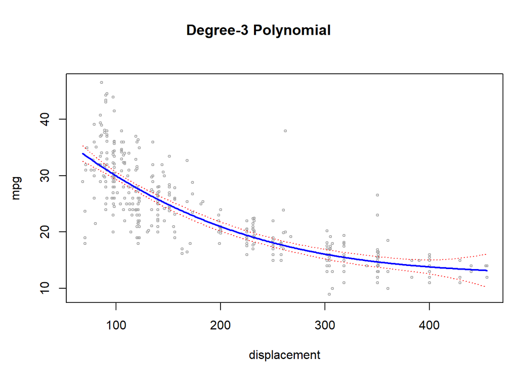

```r
par(mfrow=c(1,1), mar=c(4.5,4.5,1,1), oma=c(0,0,4,0))
plot(displacement, mpg, xlim=dispRange, cex =.5, col="darkgrey ")
title("Degree-3 Polynomial",outer=T)
lines(dispList, preds$fit, lwd=2, col="blue")
matlines(dispList, se.bands, lwd=1, col="red", lty=3)
```

Plot shows predicted MPG against all possible displacements within our data range. The blue line is our predicted amount while the dotted red lines are our 95% confidence intervals. Notice how where there are more data points, the confidence interval is closer to our prediction.

```r
table(cut(displacement,4))
```

```
##
## (67.6,165]  (165,262]  (262,358]  (358,455]
##        213         78         72         29
```

```r
fit=lm(mpg~cut(displacement,4))
coef(summary(fit))
```

```
##                                 Estimate Std. Error   t value      Pr(>|t|)
## (Intercept)                    28.809859  0.3367162  85.56125 5.985649e-254
## cut(displacement, 4)(165,262]  -9.118834  0.6503741 -14.02091  2.025407e-36
## cut(displacement, 4)(262,358] -13.234859  0.6699158 -19.75601  1.279022e-60
## cut(displacement, 4)(358,455] -15.120204  0.9726861 -15.54479  1.053906e-42
```

Creating four equal bins based off of displacement range. Bin 1: 67.6 -> 165 Bin 2: 165.1 -> 262 …

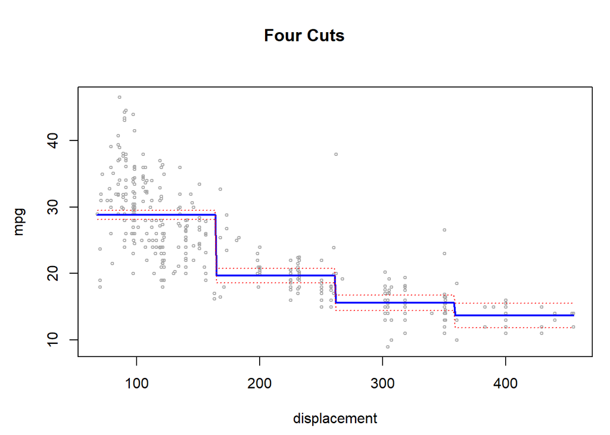

```r
preds = predict(fit, newdata=list(displacement=dispList), se=TRUE)
se.bands = cbind(preds$fit+2*preds$se.fit, preds$fit-2*preds$se.fit)

par(mfrow=c(1,1), mar=c(4.5,4.5,1,1), oma=c(0,0,4,0))
plot(displacement, mpg, xlim=dispRange, cex =.5, col="darkgrey ")
title("Four Cuts",outer=T)
lines(dispList, preds$fit, lwd=2, col="blue")
matlines(dispList, se.bands, lwd=1, col="red", lty=3)
```

Showing the predictions and 95% CI for the four bins. Notice the distance between the predictions and intervals as data becomes more sparse (larger SE).